# capitulo1

Pedro Ivo Vasconcelos - TP

## **Capítulo 1**

1. Os arquivos foram baixados
2. A execução dos scripts está abaixo, no primeiro bloco se encontra o *simrk_ph_teste* e depois *simrk_ph_CD*

```python
import os
```

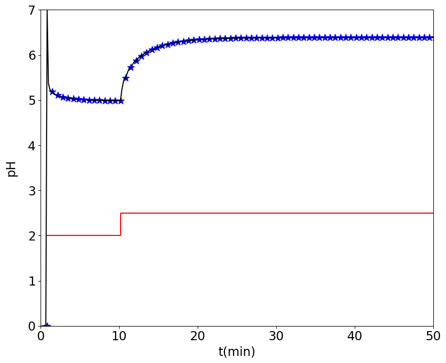

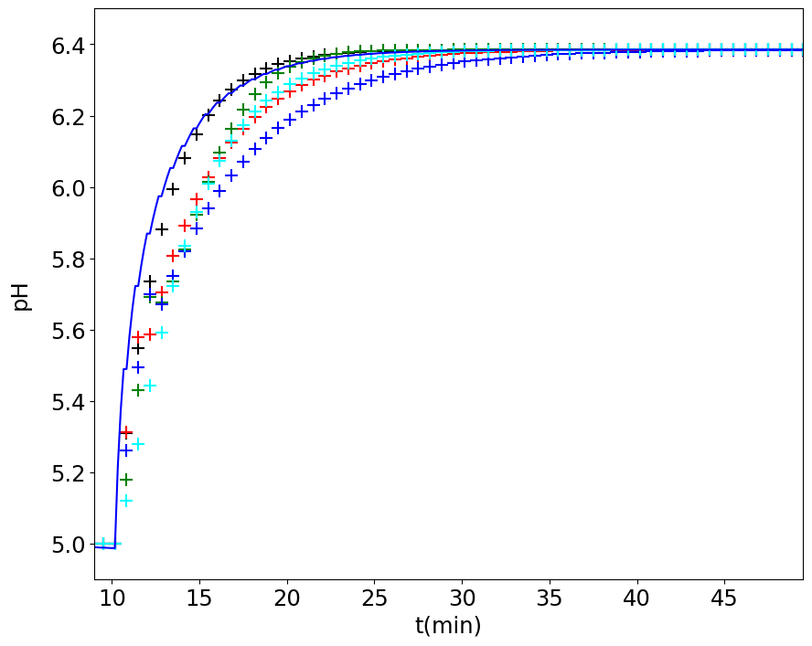

```python
%run modelo_planta_ph/simrk_ph_teste.py
```

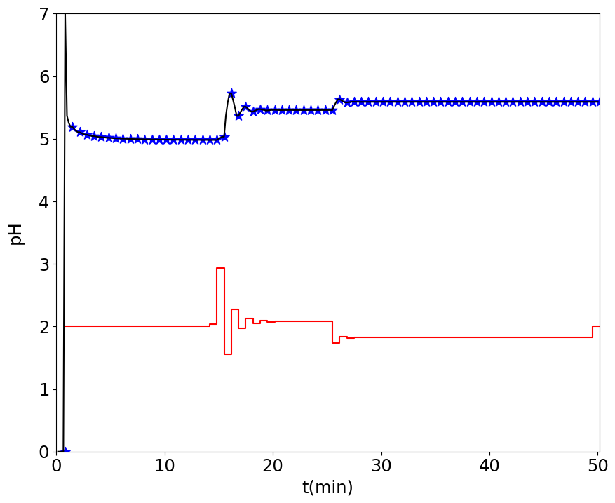

```python
%run modelo_planta_ph/simrk_ph_CD.py
```

3. O fluxograma se encontra no final do bloco de texto.

A simulação é realizada nas seguintes partes no arquivo smirk_ph_teste:

- Entrada de solução ácida: Linha 36 e 37 (Matlab) e linha 253 a 254 (Python)
- Entrada de solução alcalina: Linha 39 e 41 (Matlab) e linha 256 a 258 (Python)
- Sistema: Linha 43 a 61 (Matlab) e linha 260 a 278 (Python)
- Resposta transitória: Linha 64 a 78 (Matlab) e linha 280 a 299 (Python)
- Ponto de operação: Linha 85 a 89 (Matlab) e linha 308 a 312 (Python)
- Step de álcali forte: Linha 91 a 93 (Matlab) e linha 314 a 316 (Python)
- Simulação: Linha 95 a 108 (Matlab) e linha 318 a 337 (Python)

[figure not shown]

4. Integração numérica é um meio de resolver integração através de métodos numéricos, que consiste em um algoritmo que contém um número finito de execuções para atender esse procedimento diferente da integral analítica que busca o valor exato através de outra função. A integração numérica é especialmente útil quando a integral exata é difícil ou impossível de se obter analicamente.

O método Runge-Kutta de Quarta Ordem consiste é um dos métodos mais conhecidos para resolver EDOs. Ele funciona tomando a média ponderada de quatro diferentes estimativas do valor da função, calculadas em diferentes pontos do intervalo.

5. Controlador Proporcional
6. Fluxograma:

[figure not shown]

A simulação é realizada nas seguintes partes no arquivo smirk_ph_CD:

- Referência: Linha 94 e 95 (Matlab) e linha 317 a 318 (Python)
- Erro: Linha 102 e 103 (Matlab) e linha 327 a 328 (Python)
- Controlador: Linha 105 e 107 (Matlab) e linha 330 a 332 (Python)
- Distúrbio: 109 e 110 (Matlab) e linha 334 a 335 (Python)
- Sys(Planta): 112 a 114 (Matlab) e linha 337 a 345 (Python)